# An Exploration of Lobbying in Chicago

Claire Herdeman

1/27/2019

# Background

The Chicago Board of Ethics requires that all lobbyists engaging with City officials register with the Board and file regular activity reports. The activity reports are filed electronically and include compensation paid to lobbyists by clients (the organizations and firms that hire lobbyists), lobbyist contributions to public and elected City officials, and lobbying activities (meetings with government departments or officials) conducted on behalf of clients.

The recent controversy surrounding unregistered lobbying by individuals contacting Mayor Rahm Emmanuel through his personal email account (see [here](https://www.chicagotribune.com/news/local/politics/ct-rahm-emanuel-emails-chicago-board-of-ethics-met-0420-20170419-story.html), [here](https://www.chicagotribune.com/news/local/politics/ct-chicago-lobbyist-registration-violations-met-0722-20170721-story.html), and [here](https://www.chicagotribune.com/news/local/politics/ct-rahm-emanuel-chicago-lobbying-violations-met-0720-20170719-story.html)), suggests that there is additional unregistered lobbying activity happening in Chicago. This analysis necessarily focuses only on registered activity reported to the City and made electronically available on the City of Chicago’s Open Data Portal.

# Lobbying Activity

[figure not shown]

```r
# aggregate by year to show trend
# what happened  in 2017? why seasonality?
# fourier transformation - time to frequency domain
# axes labels, label quarter only, year underneath
# move legend onto plot

# Summarise data into necessary format
#act_summ <-

activity %>%
  mutate(year = format(PERIOD_START, '%Y'),
         PERIOD_START = as.yearqtr(PERIOD_START, format = "%Y-%m-%d")) %>%
  group_by(year, ACTION) %>%
  summarise(n = n()) %>%
  ggplot(aes(year, n)) +
    geom_line(aes(group=ACTION, color=ACTION), size = 1) +
    scale_color_manual(values = c("#3B9AB2", "#EBCC2A", "#F21A00")) +
    labs(title="Growth in administrative actions has outpaced others since 2016",
        subtitle="Quarterly Lobbying Actions by Type, 2012 - 2018",
        caption="Source: City of Chicago Lobbyist Data, Activity",
        x = "Years",
        y = "Number of Lobbying Actions") +
    theme_minimal() +
    theme(#axis.text.x = element_text(angle = 90, hjust = 1),
        plot.caption = element_text(hjust = 0),
        legend.position = c(0.15, 0.8),
        legend.background = element_rect(colour = 'black', fill = 'white', linetype='solid'))
```

# Private Industries Use Lobbyists to Influence Government

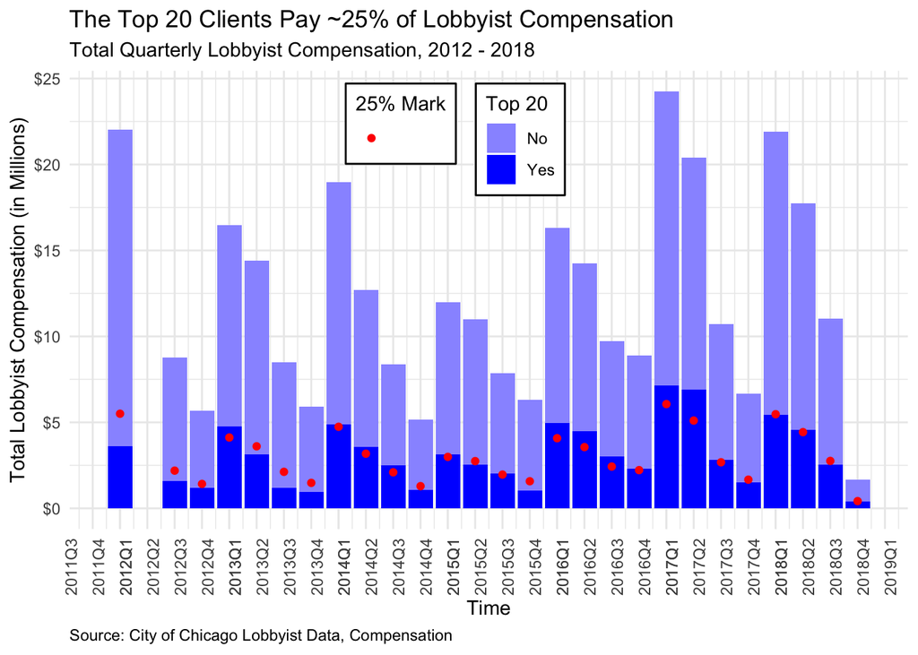

```r
# Top 25 flag
top_20 <- compensation %>%
  group_by(CLIENT_NAME) %>%
  summarise(sum = sum(COMPENSATION_AMOUNT), cnt = n()) %>%
  arrange(desc(sum)) %>%
  slice(1:20) %>%
  select(CLIENT_NAME)

compensation %<>% mutate(TOP20 = ifelse(CLIENT_NAME %in% top_20$CLIENT_NAME, "Yes", "No"))

c <- compensation %>%
  mutate(PERIOD_START = as.yearqtr(PERIOD_START, format = "%Y-%m-%d")) %>%
  #filter(PERIOD_START < as.Date('2018-07-01')) %>%
  group_by(TOP20, PERIOD_START) %>%
  summarise(sum = sum(COMPENSATION_AMOUNT), n = n()) %>%
  mutate(sum = sum/1000000) %>%
  ggplot(aes(PERIOD_START, sum)) +
    geom_col(aes(fill=factor(TOP20, levels=c("No","Yes")))) +
    scale_y_continuous(label=dollar_format()) +
    scale_x_yearqtr(limits = c('2012 Q1', '2018 Q4'), format = "%YQ%q", n = 28) +
    scale_fill_manual(values=c("#9999ff", "#0000ff")) +
    labs(title="The Top 20 Clients Pay ~25% of Lobbyist Compensation",
         subtitle="Total Quarterly Lobbyist Compensation, 2012 - 2018",
         caption="Source: City of Chicago Lobbyist Data, Compensation",
         x = "Time",
         y = "Total Lobbyist Compensation (in Millions)") +
  theme_minimal() +
  theme(axis.text.x = element_text(angle = 90, hjust = 1),
        plot.caption = element_text(hjust = 0),
        legend.box = 'horizontal',
        legend.position = c(0.46, 0.85),
        legend.background = element_rect(colour = 'black', fill = 'white', linetype='solid')) +
  guides(fill=guide_legend(title="Top 20"))

c + geom_point(data = compensation %>%
  mutate(PERIOD_START = as.yearqtr(PERIOD_START, format = "%Y-%m-%d")) %>%
  #filter(PERIOD_START < as.Date('2018-07-01')) %>%
  group_by(PERIOD_START) %>%
  summarise(pct_25 = sum(COMPENSATION_AMOUNT) * .25/1000000, n = n()), aes(PERIOD_START, pct_25, color = '#ff0000')) +
  scale_color_identity(name = "25% Mark",
                      labels = c(""),
                      guide = "legend")
```

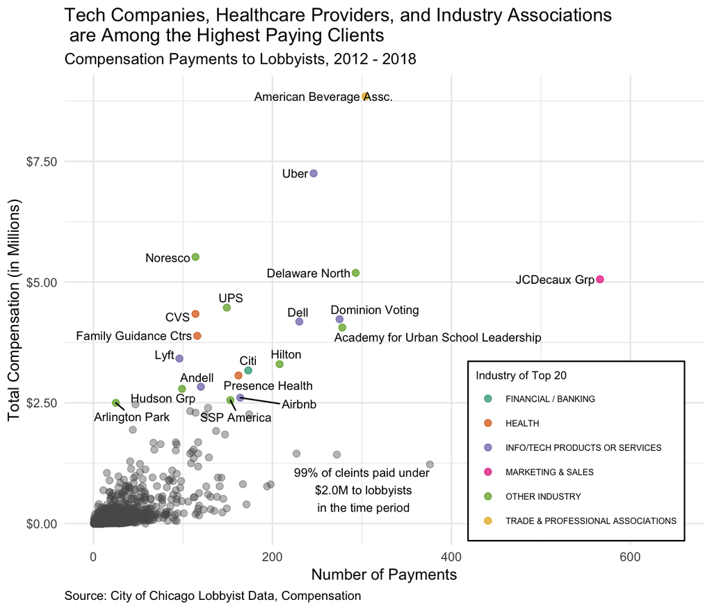

```r
# Map actual name to target name
keys <- c("ACADEMY FOR URBAN SCHOOL LEADERSHIP", "AIRBNB", "AMERICAN BEVERAGE ASSOCIATION", "ANDELL INC", "ARLINGTON PARK", "CITIBANK, NA",
          "CVS CAREMARK CORP", "DELAWARE NORTH COMPANIES", "DELL", "DOMINION VOTING SYSTEMS INC", "FAMILY GUIDANCE CENTERS INC",
          "HILTON WORLDWIDE", "HUDSON GROUP", "JCDECAUX GROUP", "LYFT", "NORESCO LLC", "PRESENCE HEALTH", "SSP AMERICA INC",
          "UBER","UNITED PARCEL SERVICE")
values <- c("Academy for Urban School Leadership", "Airbnb", "American Beverage Assc.", "Andell", "Arlington Park", "Citi",
            "CVS", "Delaware North", "Dell", "Dominion Voting", "Family Guidance Ctrs",
            "Hilton", "Hudson Grp", "JCDecaux Grp", "Lyft", "Noresco", "Presence Health", "SSP America",
            "Uber", "UPS")
nick_name <- setNames(as.list(values), keys)

top <- compensation %>%
  filter(TOP20 == 'Yes') %>%
  group_by(CLIENT_NAME, CLIENT_INDUSTRY) %>%
  summarise(sum=sum(COMPENSATION_AMOUNT), n = n()) %>%
  mutate(sum = sum/1000000,
         INDUSTRY = if_else(CLIENT_INDUSTRY %in% c('HOSPITALITY / RESTAURANT', 'PUBLIC UTILITIES',
                                                   'RETAIL', 'EDUCATION', 'RACING & WAGERING', 'TRANSPORTATION'),
                            'OTHER INDUSTRY', CLIENT_INDUSTRY),
         NICK_NAME = nick_name[CLIENT_NAME])

t <-compensation %>%
  filter(TOP20 == 'No') %>%
  group_by(CLIENT_NAME) %>%
  summarise(sum=sum(COMPENSATION_AMOUNT), n = n()) %>%
  mutate(sum = sum/1000000) %>%
  ggplot() +
    geom_point(aes(n, sum), color = '#595959', size = 2, alpha = 0.4) +
    annotate("text", x = 300, y = .7, label = "99% of cleints paid under\n $2.0M to lobbyists\n in the time period", size = 3)

t + geom_point(data = top, aes(n, sum, color = INDUSTRY), size = 2, alpha = 0.7) +
    geom_text_repel(data = top, aes(n, sum, label = NICK_NAME), check_overlap = TRUE, size = 3, hjust = 0, nudge_x = 0.1) +
    scale_y_continuous(label=dollar_format()) +
    scale_color_manual(values = brewer.pal(n=6, name="Dark2")) +
    xlim(0, 650) +
    labs(title="Tech Companies, Healthcare Providers, and Industry Associations\n are Among the Highest Paying Clients",
         subtitle="Compensation Payments to Lobbyists, 2012 - 2018",
         caption="Source: City of Chicago Lobbyist Data, Compensation",
         x = "Number of Payments",
         y = "Total Compensation (in Millions)") +
    theme_minimal() +
    theme(plot.caption = element_text(hjust = 0),
          legend.text=element_text(size=6),
          legend.title=element_text(size=8),
          legend.position = c(0.8, 0.2),
          legend.background = element_rect(colour = 'black', fill = 'white', linetype='solid')) +
  guides(color=guide_legend(title="Industry of Top 20"))
```

```r
#activity %>% filter(str_detect(CLIENT_NAME, 'ACADEMY FOR URBAN'))
```

In contrast to the vast majority of clients, the top 20 clients in terms of compensation to lobbyists each paid over $2.5M between 2012 and 2018. While any organization, including non-profits and other public service entities, may lobby government, the top 20 clients are almost all private companies with a national profile. The top spender, the American Beverage Association, has consistently paid lobbyists to advocate to the Mayor and City Council against legislation like the proposed Soda Tax and a ban on high-caffeine energy drinks proposed in 2013. Technology companies including Uber, Lyft, and Dell also rank high on the list.

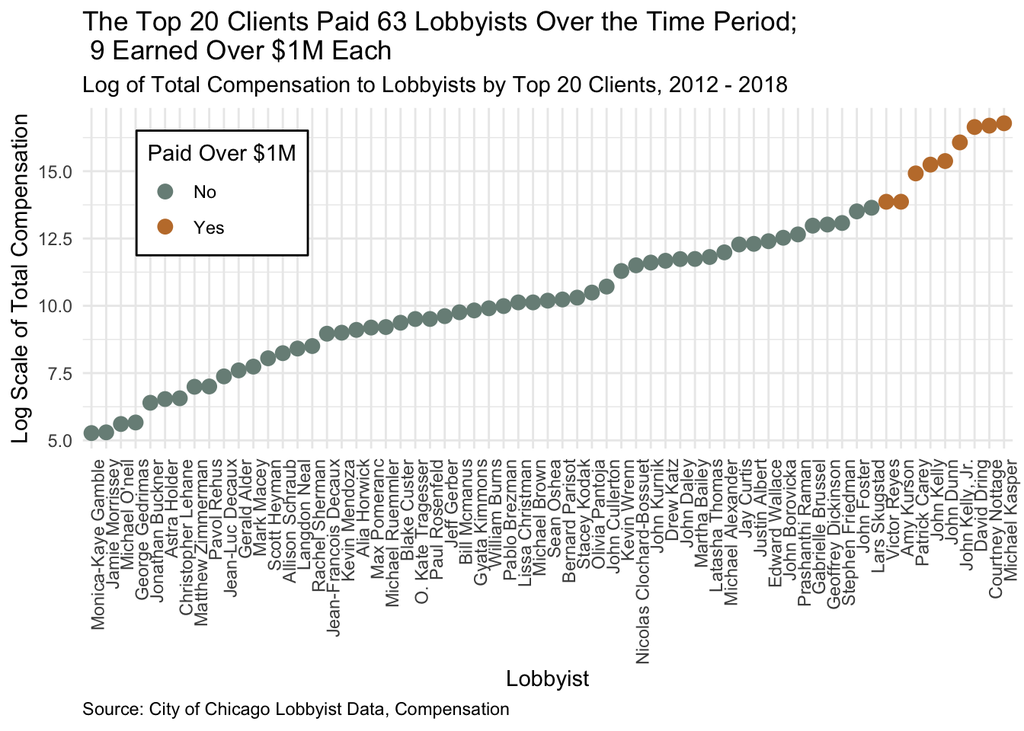

```r
# try log scale? add annotation,
compensation %>%
  filter(TOP20 == 'Yes') %>%
  group_by(LOBBYIST_NAME) %>%
  summarise(sum = sum(COMPENSATION_AMOUNT), log_sum = log(sum(COMPENSATION_AMOUNT)), n = n()) %>%
  mutate(sum = sum/1000000,
         cat = if_else(sum < 1, 'No', 'Yes')) %>%
  ggplot(aes(reorder(tools::toTitleCase(tolower(LOBBYIST_NAME)), log_sum), log_sum)) +
    geom_point(aes(color = cat), stat = 'identity', size = 3) +
    scale_color_manual(values = wes_palette(n=2, name="Moonrise2")) +
    labs(title="The Top 20 Clients Paid 63 Lobbyists Over the Time Period;\n 9 Earned Over $1M Each",
         subtitle="Log of Total Compensation to Lobbyists by Top 20 Clients, 2012 - 2018",
         caption="Source: City of Chicago Lobbyist Data, Compensation",
         x = "Lobbyist",
         y = "Log Scale of Total Compensation") +
    theme_minimal() +
    theme(axis.text.x = element_text(angle = 90, hjust = 1),
          plot.caption = element_text(hjust = 0),
          legend.position = c(0.15, 0.75),
          legend.background = element_rect(colour = 'black', fill = 'white', linetype='solid')) +
    guides(color=guide_legend(title="Paid Over $1M"))
```

```r
paid_by_top20 <- compensation %>%
  filter(TOP20 == 'Yes') %>% group_by(LOBBYIST_NAME) %>%
  summarise(sum = sum(COMPENSATION_AMOUNT), n = n())
```

Between 2012 and 2018, the top 20 clients paid 63 lobbyists to represent their interest, with 9 earning over $1M. David Drink, Courtney Nottage, and Michael Kasper, all employees of the lawfirm Fletcher, O’Brien, Kasper, and Nottage, earned over $15M each.

# Direct Influence on City Council

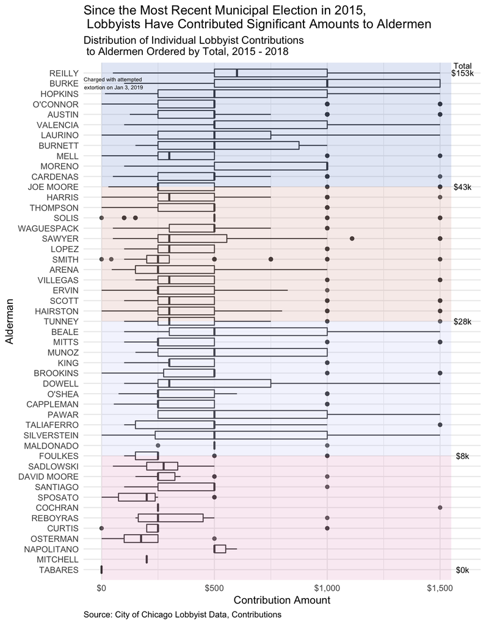

```r
# demphasize names
# annotate burke
# dont color
# quartiles for amounts, maybe box?
# annotated legend at bottom of how box plot works - oconnor
# meh background gray
# repeate x axis on quartiles?
# highlight committee charis or finance commities?

council_last <- str_trim(toupper(str_extract(council$` Person Name`, '^[A-Za-z\']+')))
#council_last
f = ""
for (last in council_last[40:52]) {
  f <- paste(f, paste('ALDERMAN = if_else(str_detect(RECIPIENT, \'',last,'\'), \'',last,'\', ALDERMAN)', sep=""), ',', sep = "")
  }
#f

alderman_contributions <- contribution %>%
  mutate(ALDERMAN = "") %>%
  mutate(ALDERMAN = if_else(str_detect(RECIPIENT, 'ARENA'), 'ARENA', ALDERMAN),
         ALDERMAN = if_else(str_detect(RECIPIENT, 'AUSTIN'), 'AUSTIN', ALDERMAN),
         ALDERMAN = if_else(str_detect(RECIPIENT, 'BEALE'), 'BEALE', ALDERMAN),
         ALDERMAN = if_else(str_detect(RECIPIENT, 'BROOKINS'), 'BROOKINS', ALDERMAN),
         ALDERMAN = if_else(str_detect(RECIPIENT, 'BURKE'), 'BURKE', ALDERMAN),
         ALDERMAN = if_else(str_detect(RECIPIENT, 'BURNETT'), 'BURNETT', ALDERMAN),
         ALDERMAN = if_else(str_detect(RECIPIENT, 'CAPPLEMAN'), 'CAPPLEMAN', ALDERMAN),
         ALDERMAN = if_else(str_detect(RECIPIENT, 'CARDENAS'), 'CARDENAS', ALDERMAN),
         ALDERMAN = if_else(str_detect(RECIPIENT, 'COCHRAN'), 'COCHRAN', ALDERMAN),
         ALDERMAN = if_else(str_detect(RECIPIENT, 'CURTIS'), 'CURTIS', ALDERMAN),
         ALDERMAN = if_else(str_detect(RECIPIENT, 'DOWELL'), 'DOWELL', ALDERMAN),
         ALDERMAN = if_else(str_detect(RECIPIENT, 'EMANUEL'), 'EMANUEL', ALDERMAN),
         ALDERMAN = if_else(str_detect(RECIPIENT, 'ERVIN'), 'ERVIN', ALDERMAN),
         ALDERMAN = if_else(str_detect(RECIPIENT, 'FOULKES'), 'FOULKES', ALDERMAN),
         ALDERMAN = if_else(str_detect(RECIPIENT, 'HAIRSTON'), 'HAIRSTON', ALDERMAN),
         ALDERMAN = if_else(str_detect(RECIPIENT, 'HARRIS'), 'HARRIS', ALDERMAN),
         ALDERMAN = if_else(str_detect(RECIPIENT, 'HOPKINS'), 'HOPKINS', ALDERMAN),
         ALDERMAN = if_else(str_detect(RECIPIENT, 'KING'), 'KING', ALDERMAN),
         ALDERMAN = if_else(str_detect(RECIPIENT, 'LAURINO'), 'LAURINO', ALDERMAN),
         ALDERMAN = if_else(str_detect(RECIPIENT, 'LOPEZ'), 'LOPEZ', ALDERMAN),
         ALDERMAN = if_else(str_detect(RECIPIENT, 'MALDONADO'), 'MALDONADO', ALDERMAN),
         ALDERMAN = if_else(str_detect(RECIPIENT, 'MELL'), 'MELL', ALDERMAN),
         ALDERMAN = if_else(str_detect(RECIPIENT, 'MITCHELL'), 'MITCHELL', ALDERMAN),
         ALDERMAN = if_else(str_detect(RECIPIENT, 'MITTS'), 'MITTS', ALDERMAN),
         ALDERMAN = if_else(str_detect(RECIPIENT, 'JOE MOORE'), 'JOE MOORE', ALDERMAN),
         ALDERMAN = if_else(str_detect(RECIPIENT, 'DAVID MOORE'), 'DAVID MOORE', ALDERMAN),
         ALDERMAN = if_else(str_detect(RECIPIENT, 'MORENO'), 'MORENO', ALDERMAN),
         ALDERMAN = if_else(str_detect(RECIPIENT, 'MUNOZ'), 'MUNOZ', ALDERMAN),
         ALDERMAN = if_else(str_detect(RECIPIENT, 'NAPOLITANO'), 'NAPOLITANO', ALDERMAN),
         ALDERMAN = if_else(str_detect(RECIPIENT, "O'CONNOR"), "O'CONNOR", ALDERMAN),
         ALDERMAN = if_else(str_detect(RECIPIENT, "O'SHEA"), "O'SHEA", ALDERMAN),
         ALDERMAN = if_else(str_detect(RECIPIENT, 'OSTERMAN'), 'OSTERMAN', ALDERMAN),
         ALDERMAN = if_else(str_detect(RECIPIENT, 'PAWAR'), 'PAWAR', ALDERMAN),
         ALDERMAN = if_else(str_detect(RECIPIENT, 'QUINN'), 'QUINN', ALDERMAN),
         ALDERMAN = if_else(str_detect(RECIPIENT, 'RAMIREZ'), 'RAMIREZ', ALDERMAN),
         ALDERMAN = if_else(str_detect(RECIPIENT, 'REBOYRAS'), 'REBOYRAS', ALDERMAN),
         ALDERMAN = if_else(str_detect(RECIPIENT, 'REILLY'), 'REILLY', ALDERMAN),
         ALDERMAN = if_else(str_detect(RECIPIENT, 'SADLOWSKI'), 'SADLOWSKI', ALDERMAN),
         ALDERMAN = if_else(str_detect(RECIPIENT, 'SANTIAGO'), 'SANTIAGO', ALDERMAN),
         ALDERMAN = if_else(str_detect(RECIPIENT, 'SAWYER'), 'SAWYER', ALDERMAN),
         ALDERMAN = if_else(str_detect(RECIPIENT, 'SCOTT'), 'SCOTT', ALDERMAN),
         ALDERMAN = if_else(str_detect(RECIPIENT, 'SILVERSTEIN'), 'SILVERSTEIN', ALDERMAN),
         ALDERMAN = if_else(str_detect(RECIPIENT, 'SMITH'), 'SMITH', ALDERMAN),
         ALDERMAN = if_else(str_detect(RECIPIENT, 'SOLIS'), 'SOLIS', ALDERMAN),
         ALDERMAN = if_else(str_detect(RECIPIENT, 'SPOSATO'), 'SPOSATO', ALDERMAN),
         ALDERMAN = if_else(str_detect(RECIPIENT, 'TABARES'), 'TABARES', ALDERMAN),
         ALDERMAN = if_else(str_detect(RECIPIENT, 'TALIAFERRO'), 'TALIAFERRO', ALDERMAN),
         ALDERMAN = if_else(str_detect(RECIPIENT, 'THOMPSON'), 'THOMPSON', ALDERMAN),
         ALDERMAN = if_else(str_detect(RECIPIENT, 'TUNNEY'), 'TUNNEY', ALDERMAN),
         ALDERMAN = if_else(str_detect(RECIPIENT, 'VALENCIA'), 'VALENCIA', ALDERMAN),
         ALDERMAN = if_else(str_detect(RECIPIENT, 'VILLEGAS'), 'VILLEGAS', ALDERMAN),
         ALDERMAN = if_else(str_detect(RECIPIENT, 'WAGUESPACK'), 'WAGUESPACK', ALDERMAN)
         ) %>%
  filter(ALDERMAN != "" & ALDERMAN != "EMANUEL")

ald_totals <- alderman_contributions %>%
  filter(CONTRIBUTION_DATE > as.Date('2014-12-31')) %>%
  group_by(ALDERMAN) %>%
  summarise(sum = sum(AMOUNT), n = n()) %>%
  arrange(desc(sum))

alderman_contributions %>%
  filter(CONTRIBUTION_DATE > as.Date('2014-12-31')) %>%
  left_join(ald_totals, by = 'ALDERMAN') %>% #glimpse()
  ggplot() +
  geom_boxplot(aes(reorder(ALDERMAN, sum), AMOUNT), alpha = 0.8) +
  coord_flip() +
  annotate("text", x = 49.7, y = 1600, label = "Total", size = 3) +
  annotate("text", x = 'REILLY', y = 1600, label = "$153k", size = 3) +
  annotate("text", x = 'JOE MOORE', y = 1600, label = "$43k", size = 3) +
  annotate("text", x = 'TUNNEY', y = 1600, label = "$28k", size = 3) +
  annotate("text", x = 'FOULKES', y = 1600, label = "$8k", size = 3) +
  annotate("text", x = 'TABARES', y = 1600, label = "$0k", size = 3) +
  annotate("rect", xmin = 'JOE MOORE', xmax = 50, ymin = 0, ymax = 1550, fill = '#7294D4', alpha = .2) +
  annotate("rect", xmin = 'TUNNEY', xmax = 'JOE MOORE', ymin = 0, ymax = 1550, fill = '#D8A499', alpha = .2) +
  annotate("rect", xmin = 'FOULKES', xmax = 'TUNNEY', ymin = 0, ymax = 1550, fill = '#C6CDF7', alpha = .2) +
  annotate("rect", xmin = 0, xmax = 'FOULKES', ymin = 0, ymax = 1550, fill = '#E6A0C4', alpha = .2) +
  annotate("text", x = 'BURKE', y = 50, label = "Charged with attempted\n extortion on Jan 3, 2019", size = 2) +
  scale_y_continuous(label=dollar_format()) +
  labs(title="Since the Most Recent Municipal Election in 2015,\n Lobbyists Have Contributed Significant Amounts to Aldermen",
         subtitle="Distribution of Individual Lobbyist Contributions\n to Aldermen Ordered by Total, 2015 - 2018",
         caption="Source: City of Chicago Lobbyist Data, Contributions",
         x = "Alderman",
         y = "Contribution Amount") +
  theme_minimal() +
  theme(plot.caption = element_text(hjust = 0))
```

[figure not shown]

```r
# shows more about who is and who isn't
# Bin lobbyists by location? octant of community areas
# sankey diagram

alderman_contributions %>%
  mutate(paid_top20 = if_else(LOBBYIST_NAME %in% paid_by_top20$LOBBYIST_NAME, TRUE, FALSE))%>%
  filter(CONTRIBUTION_DATE > as.Date('2014-12-31') & paid_top20) %>%
  left_join(ald_totals, by = 'ALDERMAN') %>%
  group_by(ALDERMAN, LOBBYIST_NAME) %>%
  summarise(sum = sum(AMOUNT), n = n()) %>%
  #arrange(desc(sum)) %>%
  ggplot() +
    geom_tile(aes(LOBBYIST_NAME, reorder(ALDERMAN, sum), fill = -sum)) +
    labs(title="Title Here",
         subtitle="Total Contributions by Top Paid Lobbyists",
         caption="Source: City of Chicago Lobbyist Data, Contributions",
         x = "Lobbyist",
         y = "Alderman") +
    theme_minimal() +
    theme(axis.text.x = element_text(angle = 90, hjust = 1),
          plot.caption = element_text(hjust = 0),)
```